# Assignment4

Prahlad

6/13/2020

# Load Packages

```r
suppressMessages(library(ggplot2))
suppressMessages(library(caret))
suppressMessages(library(e1071))
library(randomForest)
```

# Read Data

```r
setwd("C:/Users/SPRAHLA2/Desktop/ml_rcourse")
#Load DataSet
df_training <- read.csv("C:/Users/SPRAHLA2/Desktop/ml_rcourse/pml-training.csv",stringsAsFactors = FALSE)
df_testing <- read.csv("C:/Users/SPRAHLA2/Desktop/ml_rcourse/pml-testing.csv",stringsAsFactors = FALSE)
```

# Understanding Data

## dimension of data

```r
#colnames of data
dim(df_training)
```

```
## [1] 19622   160
```

**160 variables**

## no of unique users

```r
#no of unique users

unique(df_training$user_name)
```

```
## [1] "carlitos" "pedro"    "adelmo"   "charles"  "eurico"   "jeremy"
```

**6 users in dataset**

## no of classes in classe

```r
#classe dependent variable

unique(df_training$classe)
```

```
## [1] "A" "B" "C" "D" "E"
```

## range of data

```r
#data recording start and end time

min(df_training$cvtd_timestamp)
```

```
## [1] "02/12/2011 13:32"
```

```r
max(df_training$cvtd_timestamp)
```

```
## [1] "30/11/2011 17:12"
```

## Are There Any Missing Value In Data?

```r
which(sapply(df_training,function(x) sum(is.na(x))/nrow(df_training)*100)>95)
```

```
##            max_roll_belt           max_picth_belt            min_roll_belt
##                       18                       19                       21
##           min_pitch_belt      amplitude_roll_belt     amplitude_pitch_belt
##                       22                       24                       25
##     var_total_accel_belt            avg_roll_belt         stddev_roll_belt
##                       27                       28                       29
##            var_roll_belt           avg_pitch_belt        stddev_pitch_belt
##                       30                       31                       32
##           var_pitch_belt             avg_yaw_belt          stddev_yaw_belt
##                       33                       34                       35
##             var_yaw_belt            var_accel_arm             avg_roll_arm
##                       36                       50                       51
##          stddev_roll_arm             var_roll_arm            avg_pitch_arm
##                       52                       53                       54
##         stddev_pitch_arm            var_pitch_arm              avg_yaw_arm
##                       55                       56                       57
##           stddev_yaw_arm              var_yaw_arm             max_roll_arm
##                       58                       59                       75
##            max_picth_arm              max_yaw_arm             min_roll_arm
##                       76                       77                       78
##            min_pitch_arm              min_yaw_arm       amplitude_roll_arm
##                       79                       80                       81
##      amplitude_pitch_arm        amplitude_yaw_arm        max_roll_dumbbell
##                       82                       83                       93
##       max_picth_dumbbell        min_roll_dumbbell       min_pitch_dumbbell
##                       94                       96                       97
##  amplitude_roll_dumbbell amplitude_pitch_dumbbell       var_accel_dumbbell
##                       99                      100                      103
##        avg_roll_dumbbell     stddev_roll_dumbbell        var_roll_dumbbell
##                      104                      105                      106
##       avg_pitch_dumbbell    stddev_pitch_dumbbell       var_pitch_dumbbell
##                      107                      108                      109
##         avg_yaw_dumbbell      stddev_yaw_dumbbell         var_yaw_dumbbell
##                      110                      111                      112
##         max_roll_forearm        max_picth_forearm         min_roll_forearm
##                      131                      132                      134
##        min_pitch_forearm   amplitude_roll_forearm  amplitude_pitch_forearm
##                      135                      137                      138
##        var_accel_forearm         avg_roll_forearm      stddev_roll_forearm
##                      141                      142                      143
##         var_roll_forearm        avg_pitch_forearm     stddev_pitch_forearm
##                      144                      145                      146
##        var_pitch_forearm          avg_yaw_forearm       stddev_yaw_forearm
##                      147                      148                      149
##          var_yaw_forearm
##                      150
```

**Yes there are missing values.67 variables have missing value % greater than 95%. We have to be careful of variable selection for model building**

# Taking only set of variables which are not having high percentage of missing value and leaving out statistical derived variables like (max,min,avg,skewness,kurtosis,variance,standard deviation) for analysis

```r
colnames(df_training)
```

```
##   [1] "X"                        "user_name"
##   [3] "raw_timestamp_part_1"     "raw_timestamp_part_2"
##   [5] "cvtd_timestamp"           "new_window"
##   [7] "num_window"               "roll_belt"
##   [9] "pitch_belt"               "yaw_belt"
##  [11] "total_accel_belt"         "kurtosis_roll_belt"
##  [13] "kurtosis_picth_belt"      "kurtosis_yaw_belt"
##  [15] "skewness_roll_belt"       "skewness_roll_belt.1"
##  [17] "skewness_yaw_belt"        "max_roll_belt"
##  [19] "max_picth_belt"           "max_yaw_belt"
##  [21] "min_roll_belt"            "min_pitch_belt"
##  [23] "min_yaw_belt"             "amplitude_roll_belt"
##  [25] "amplitude_pitch_belt"     "amplitude_yaw_belt"
##  [27] "var_total_accel_belt"     "avg_roll_belt"
##  [29] "stddev_roll_belt"         "var_roll_belt"
```

[output cut: 65 more lines]

## data variable selection

```r
df_training_selected <- df_training[,c("user_name","cvtd_timestamp","new_window","num_window","roll_belt","pitch_belt","yaw_belt","total_accel_belt","roll_arm","pitch_arm","yaw_arm","total_accel_arm","roll_dumbbell","pitch_dumbbell","yaw_dumbbell","total_accel_dumbbell","roll_forearm","pitch_forearm","yaw_forearm","total_accel_forearm","classe")]
```

## check missing value %

```r
sapply(df_training_selected,function(x) sum(is.na(x))/nrow(df_training)*100)
```

```
##            user_name       cvtd_timestamp           new_window
##                    0                    0                    0
##           num_window            roll_belt           pitch_belt
##                    0                    0                    0
##             yaw_belt     total_accel_belt             roll_arm
##                    0                    0                    0
##            pitch_arm              yaw_arm      total_accel_arm
##                    0                    0                    0
##        roll_dumbbell       pitch_dumbbell         yaw_dumbbell
##                    0                    0                    0
## total_accel_dumbbell         roll_forearm        pitch_forearm
##                    0                    0                    0
##          yaw_forearm  total_accel_forearm               classe
##                    0                    0                    0
```

# Exploratory Analysis(Only 5 plots are recommended so i am picking just one variable in each of arm,dumbbell,forearm,belt from selected variable done in the above step)

## Usage of belt,arm,dumbbell,forearm among users each day(4 days!)

```r
df_training_selected$day <- as.character(as.Date(df_training_selected$cvtd_timestamp,"%d/%m/%Y"))
table(df_training_selected$user_name,df_training_selected$day)
```

```
##
##            2011-11-28 2011-11-30 2011-12-02 2011-12-05
##   adelmo            0          0       3892          0
##   carlitos          0          0          0       3112
##   charles           0          0       3536          0
##   eurico         3070          0          0          0
##   jeremy            0       3402          0          0
##   pedro             0          0          0       2610
```

## Performance of classe exercise around belt

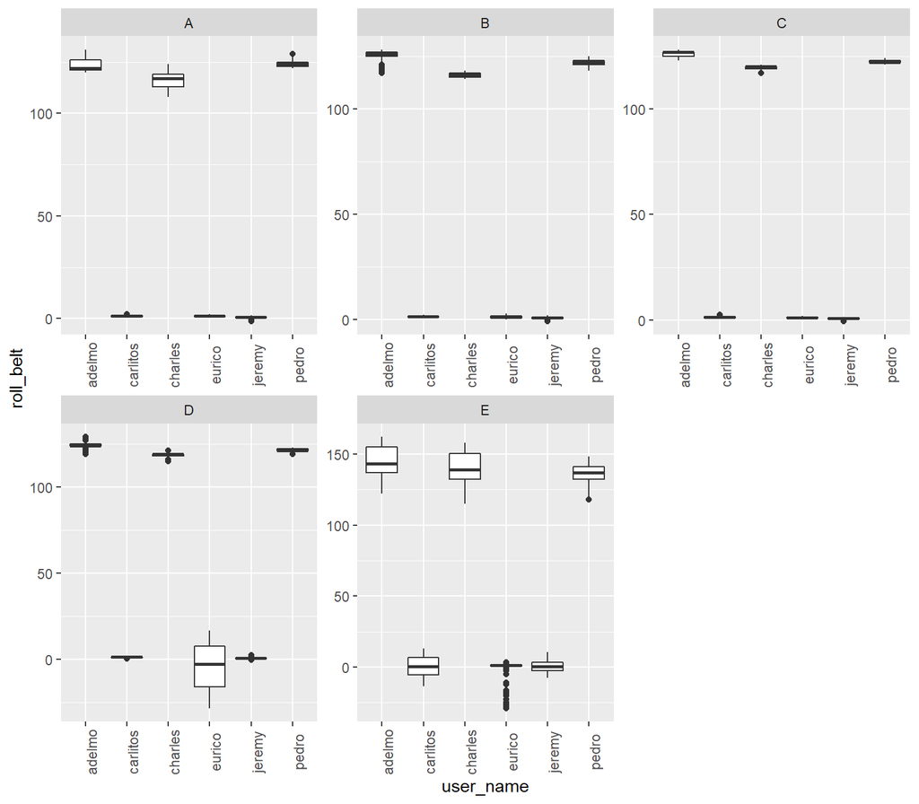

## Performance of classe exercise around arm

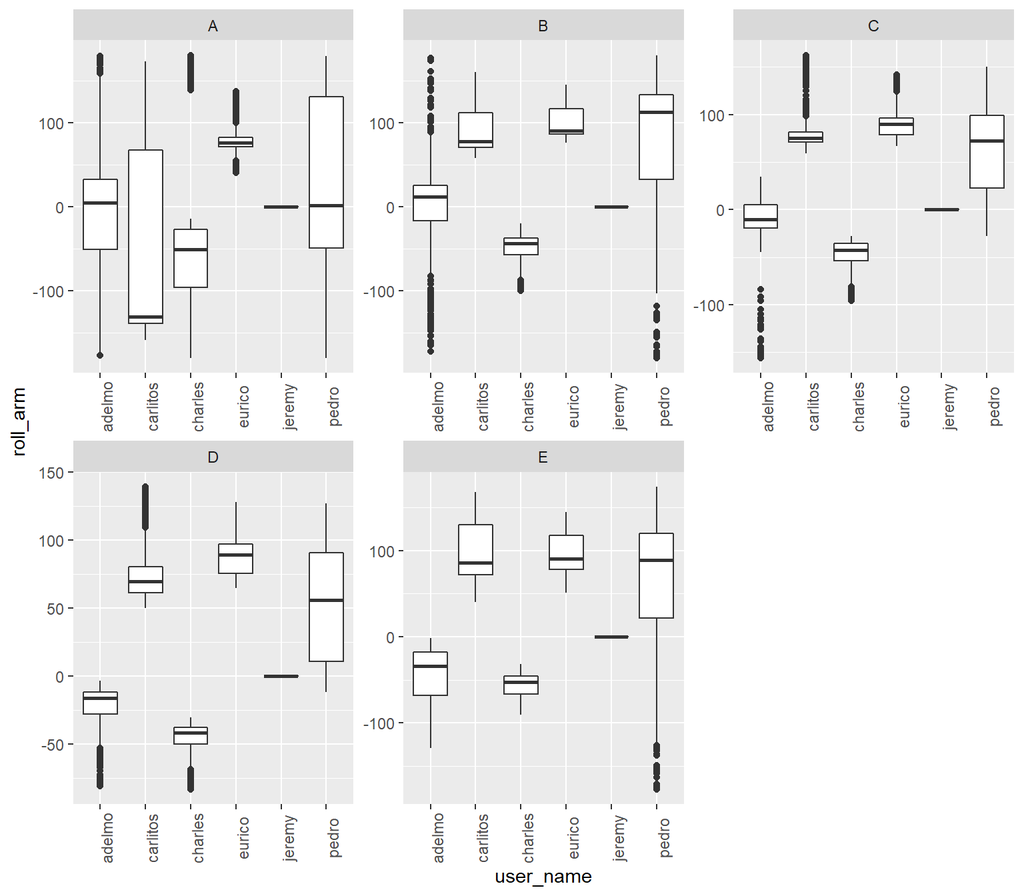

## Performance of classe exercise around fore arm

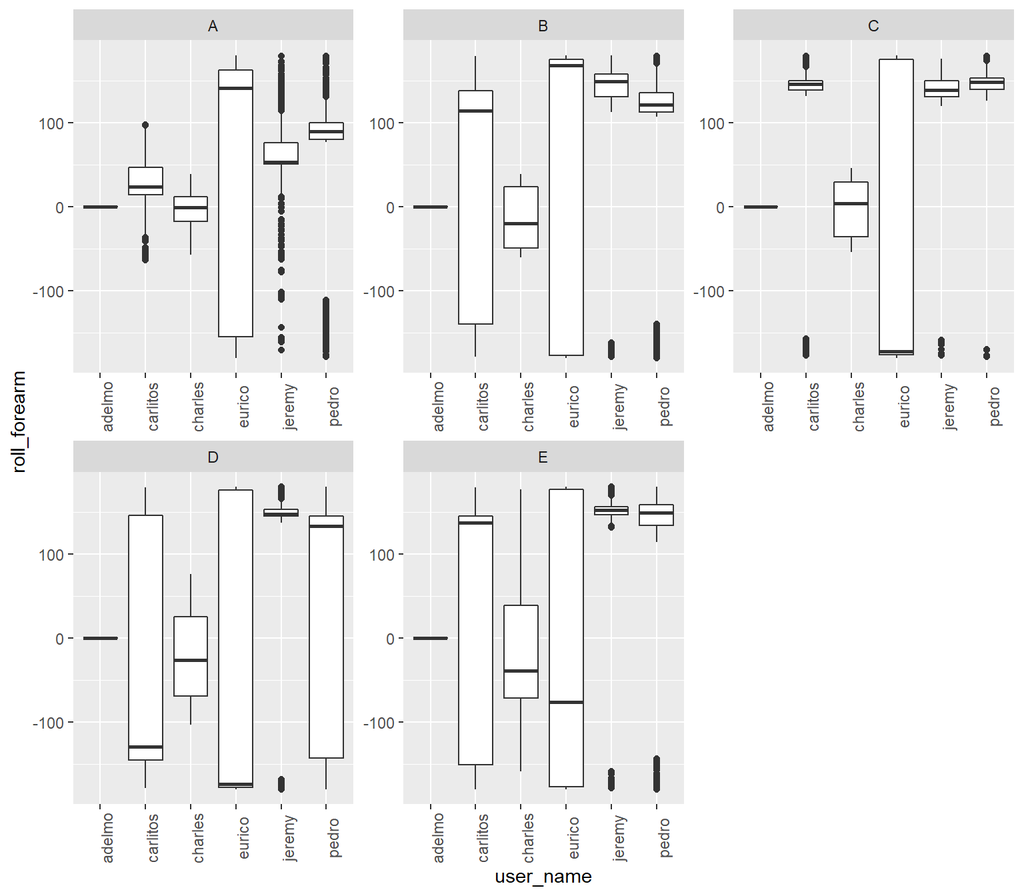

## Performance of classe exercise around dumbbell

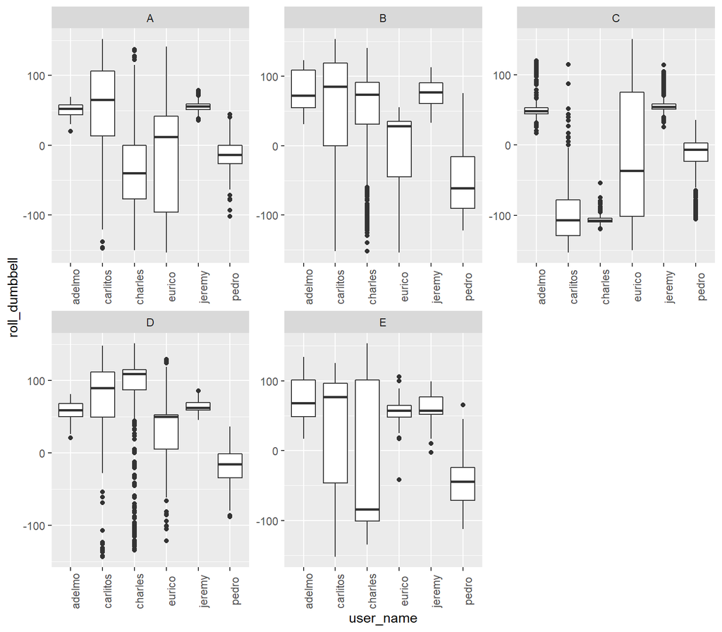

**There is variablity in each user for each classe**

## Check For Multicollinearity Between Numerical Variables

```r
suppressMessages(library(pander))
p <- sapply(df_training_selected,function(x) is.numeric(x))
t <- df_training_selected[,p]
#Remove Na's
q1 <- na.omit(t)
c <-as.data.frame(cor(q1))
panderOptions('table.split.table', Inf)
pander(c)
```

|  | num_window | roll_belt | pitch_belt | yaw_belt | total_accel_belt | roll_arm | pitch_arm | yaw_arm | total_accel_arm | roll_dumbbell | pitch_dumbbell | yaw_dumbbell | total_accel_dumbbell | roll_forearm | pitch_forearm | yaw_forearm | total_accel_forearm |
| --- | --- | --- | --- | --- | --- | --- | --- | --- | --- | --- | --- | --- | --- | --- | --- | --- | --- |
| **num_window** | 1 | 0.07198 | -0.1023 | 0.08589 | 0.06603 | -0.1199 | -0.03388 | -0.04798 | -0.06455 | 0.03407 | -0.1527 | -0.1084 | 0.08873 | -0.01113 | -0.04697 | -0.08413 | -0.02651 |
| **roll_belt** | 0.07198 | 1 | -0.2159 | 0.8152 | 0.9809 | -0.372 | 0.05977 | -0.2259 | -0.2783 | -0.1265 | 0.06403 | 0.02564 | -0.1921 | -0.1502 | 0.1746 | -0.2664 | 0.06556 |
| **pitch_belt** | -0.1023 | -0.2159 | 1 | -0.6998 | -0.139 | 0.1702 | -0.1615 | 0.1434 | 0.09302 | -0.3502 | 0.2316 | 0.66 | -0.3175 | 0.1452 | 0.2536 | 0.04851 | -0.3293 |
| **yaw_belt** | 0.08589 | 0.8152 | -0.6998 | 1 | 0.7621 | -0.3369 | 0.1362 | -0.2286 | -0.2407 | 0.09713 | -0.09312 | -0.3477 | 0.04576 | -0.1807 | -0.03071 | -0.1957 | 0.2278 |
| **total_accel_belt** | 0.06603 | 0.9809 | -0.139 | 0.7621 | 1 | -0.3615 | 0.05361 | -0.2104 | -0.266 | -0.1314 | 0.05895 | 0.06043 | -0.1714 | -0.1127 | 0.1845 | -0.2387 | 0.03222 |
| **roll_arm** | -0.1199 | -0.372 | 0.1702 | -0.3369 | -0.3615 | 1 | -0.04136 | 0.407 | 0.05771 | -0.1492 | 0.2286 | 0.2796 | -0.1554 | 0.07588 | 0.1657 | 0.2365 | -0.01191 |
| **pitch_arm** | -0.03388 | 0.05977 | -0.1615 | 0.1362 | 0.05361 | -0.04136 | 1 | -0.08235 | 0.03089 | 0.02154 | -0.1526 | -0.1784 | 0.1972 | 0.02287 | -0.1545 | 0.07977 | 0.1089 |
| **yaw_arm** | -0.04798 | -0.2259 | 0.1434 | -0.2286 | -0.2104 | 0.407 | -0.08235 | 1 | -0.01491 | -0.125 | 0.08696 | 0.1443 | -0.06311 | 0.05716 | 0.06093 | 0.1845 | -0.1129 |
| **total_accel_arm** | -0.06455 | -0.2783 | 0.09302 | -0.2407 | -0.266 | 0.05771 | 0.03089 | -0.01491 | 1 | -0.005293 | -0.07226 | -0.02883 | 0.137 | 0.02375 | -0.1867 | 0.09288 | -0.07364 |
| **roll_dumbbell** | 0.03407 | -0.1265 | -0.3502 | 0.09713 | -0.1314 | -0.1492 | 0.02154 | -0.125 | -0.005293 | 1 | 0.2129 | -0.2771 | 0.3599 | -0.02392 | -0.1083 | -0.0002381 | 0.1871 |
| **pitch_dumbbell** | -0.1527 | 0.06403 | 0.2316 | -0.09312 | 0.05895 | 0.2286 | -0.1526 | 0.08696 | -0.07226 | 0.2129 | 1 | 0.5174 | -0.4052 | -0.07236 | 0.2908 | -0.09264 | 0.01484 |
| **yaw_dumbbell** | -0.1084 | 0.02564 | 0.66 | -0.3477 | 0.06043 | 0.2796 | -0.1784 | 0.1443 | -0.02883 | -0.2771 | 0.5174 | 1 | -0.5267 | 0.01276 | 0.2804 | -0.05579 | -0.1894 |
| **total_accel_dumbbell** | 0.08873 | -0.1921 | -0.3175 | 0.04576 | -0.1714 | -0.1554 | 0.1972 | -0.06311 | 0.137 | 0.3599 | -0.4052 | -0.5267 | 1 | 0.219 | -0.3449 | 0.2289 | 0.1257 |
| **roll_forearm** | -0.01113 | -0.1502 | 0.1452 | -0.1807 | -0.1127 | 0.07588 | 0.02287 | 0.05716 | 0.02375 | -0.02392 | -0.07236 | 0.01276 | 0.219 | 1 | -0.05441 | 0.3467 | -0.08146 |
| **pitch_forearm** | -0.04697 | 0.1746 | 0.2536 | -0.03071 | 0.1845 | 0.1657 | -0.1545 | 0.06093 | -0.1867 | -0.1083 | 0.2908 | 0.2804 | -0.3449 | -0.05441 | 1 | -0.2208 | -0.1793 |
| **yaw_forearm** | -0.08413 | -0.2664 | 0.04851 | -0.1957 | -0.2387 | 0.2365 | 0.07977 | 0.1845 | 0.09288 | -0.0002381 | -0.09264 | -0.05579 | 0.2289 | 0.3467 | -0.2208 | 1 | 0.1998 |
| **total_accel_forearm** | -0.02651 | 0.06556 | -0.3293 | 0.2278 | 0.03222 | -0.01191 | 0.1089 | -0.1129 | -0.07364 | 0.1871 | 0.01484 | -0.1894 | 0.1257 | -0.08146 | -0.1793 | 0.1998 | 1 |

**Multi collinearity exists but since we are building tree based models including rf where each tree is different.we can try to remove them in further iterations**

# Model Building

## distribution of classe variable

```r
table(df_training_selected$classe)
```

```
##
##    A    B    C    D    E
## 5580 3797 3422 3216 3607
```

## Building a default RF with no hyper parameters and OOB is a CV metric

## 1)Since the user names are same in both train and test we can use user name

## 2) dropping new wndow as test set only has value “no”

```r
#convert dependent to factor
df_training_selected$classe <- as.factor(df_training_selected$classe)

# dropping unwanted column

df_training_selected$day <- NULL

#character to factor
df_training_selected$new_window <- as.factor(df_training_selected$new_window)
df_training_selected$user_name <- as.factor(df_training_selected$user_name)

set.seed(3457)

#training
model_rf <- randomForest(classe~.-cvtd_timestamp-new_window,data=df_training_selected)

model_rf
```

```
##
## Call:
##  randomForest(formula = classe ~ . - cvtd_timestamp - new_window,      data = df_training_selected)
##                Type of random forest: classification
##                      Number of trees: 500
## No. of variables tried at each split: 4
##
##         OOB estimate of  error rate: 0.09%
## Confusion matrix:
##      A    B    C    D    E  class.error
## A 5580    0    0    0    0 0.0000000000
## B    1 3795    0    1    0 0.0005267316
## C    0    4 3416    2    0 0.0017533606
## D    0    1    1 3213    1 0.0009328358
## E    0    0    3    3 3601 0.0016634322
```

## Varimp

```r
varImp(model_rf)
```

```
##                        Overall
## user_name             457.9678
## num_window           2942.2121
## roll_belt            1936.1633
## pitch_belt           1253.7556
## yaw_belt             1541.9041
## total_accel_belt      538.2202
## roll_arm              524.8097
## pitch_arm             272.3909
## yaw_arm               437.8473
## total_accel_arm       233.3761
## roll_dumbbell         843.3334
## pitch_dumbbell        451.4661
## yaw_dumbbell          626.2025
## total_accel_dumbbell  689.6410
## roll_forearm          930.6746
## pitch_forearm        1225.7259
## yaw_forearm           384.6047
## total_accel_forearm   220.3053
```

# Prediction on test data

```r
df_testing_selected <- df_testing[,c("user_name","cvtd_timestamp","new_window","num_window","roll_belt","pitch_belt","yaw_belt","total_accel_belt","roll_arm","pitch_arm","yaw_arm","total_accel_arm","roll_dumbbell","pitch_dumbbell","yaw_dumbbell","total_accel_dumbbell","roll_forearm","pitch_forearm","yaw_forearm","total_accel_forearm")]

#character to factor
df_testing_selected$new_window <- as.factor(df_testing_selected$new_window)
df_testing_selected$user_name <- as.factor(df_testing_selected$user_name)

predictions <- predict(model_rf,df_testing_selected)

predictions
```

```
##  1  2  3  4  5  6  7  8  9 10 11 12 13 14 15 16 17 18 19 20
##  B  A  B  A  A  E  D  B  A  A  B  C  B  A  E  E  A  B  B  B
## Levels: A B C D E
```